# 6414_SP22_Midterm_2_Part_2_Starter_Template

## Midterm Exam 2 -Open Book Section (R) - Part 2

## Instructions

The R Markdown/Jupyter Notebook file includes the questions, the empty code chunk sections for your code, and the text blocks for your responses. Answer the questions below by completing the R Markdown/Jupyter Notebook file. You may make slight adjustments to get the file to knit/convert but otherwise keep the formatting the same. Once you've finished answering the questions, submit your responses in a single knitted file as **HTML** only.

There are 9 questions total, each worth between 3.5 and 9 points. Partial credit may be given if your code is correct, but your conclusion is incorrect or vice versa.

*Next Steps:*

1. Save the .Rmd/.ipnyb file in your R working directory - the same directory where you will download the "crime.csv" data file into. Having both files in the same directory will help in reading the "crime.csv" file.
2. Read the question and create the R code necessary within the code chunk section immediately below each question. Knitting this file will generate the output and insert it into the section below the code chunk.
3. Type your answer to the questions in the text block provided immediately after the response prompt.
4. Once you've finished answering all questions, knit this file and submit the knitted file *as HTML* on Canvas.

   ```
   * Make sure to start submission of the exam at least 10 minutes before the end of the exam time. It is your responsibility to keep track of your time and submit before the time limit.

   * If you are unable to knit your file as HTML for whatever reason, you may upload your Rmd/ipynb/PDF/Word file instead. Incidents will be dealt with on a case-by-case basis. However, if you fail to submit the knitted file because you didn't leave enough time (>=10 minutes) to knit and submit your file, you will be penalized 10%.

   * If you are unable to upload your exam file for whatever reason, you may IMMEDIATELY attach the file to the exam page as a comment via Grades-> Midterm Exam 2 - Open Book Section (R) - Part 2 -> Comment box.

   * Note that you will be penalized 10% (or more) if the submission is made within 5 minutes after the exam time has expired and a higher penalty if more than 5 minutes. Furthermore, you will receive zero points if the submission is made after 15 minutes of the exam time expiring. We will not allow later submissions or re-taking of the exam.

   * If you upload your file after the exam closes, let the instructors know via a private Piazza post. Please DON'T attach the exam file via a private Piazza post to the instructors since you could compromise the exam process. Any submission received via Piazza will not be considered.
   ```

### Mock Example Question

This will be the exam question - each question is already copied from Canvas and inserted into individual text blocks below, *you do not need to copy/paste the questions from the online Canvas exam.*

```r
# Example code chunk area. Enter your code below the comment
```

**Mock Response to Example Question**: This is the section where you type your written answers to the question. Depending on the question asked, your typed response may be a number, a list of variables, a few sentences, or a combination of these elements.

**Ready? Let's begin.**

## Background

In this exam, you will be considering various socio-economic attributes of communities within different counties in the US and use the given data to predict total number of violent crimes per 1000 population (*ViolentCrimesPerPop*).

The data in "crime.csv" contains 1993 data points with the following 12 attributes:

1. *PersPerOccupHous*: mean persons per household
2. *PctHousOwnOcc*: percent of households owner occupied
3. *MalePctDivorce*: percentage of males who are divorced
4. *FamInc*: Family income category: Low/Medium/High (Qualitative)
5. *PctRecImmig8*: percent of population who have immigrated within the last 8 years
6. *NormPopulation*: Normalized population for community
7. *Rent*: Median Rent category:Low/Medium/High (Qualitative)
8. *PctPopUnderPov*: percentage of people under the poverty level
9. *PctLess9thGrade*: percentage of people 25 and over with less than a 9th grade education
10. *PctUnemployed*: percentage of people 16 and over, in the labor force, and unemployed
11. *NumStreet*: number of homeless people counted in the street
12. *ViolentCrimesPerPop*: total number of violent crimes per 1000 population

## Read the data

Read the data and answer the questions below using the supplied R Markdown file.

```r
# Load relevant libraries (add here if needed)
library(car)
library(aod)
library(MASS)

# Read the data set
crime_full = read.csv("crime.csv", header = TRUE)

# Split the data into training and testing sets
set.seed(6414)
sample_size = floor(0.8 * nrow(crime_full))
picked = sample(seq_len(nrow(crime_full)), size = sample_size)

crime = crime_full[picked,]
crime_test = crime_full[-picked,]
```

**Note:** Use *crime* as your data set for the following questions unless otherwise stated.

**Note:** For all of the following questions, treat all variables as quantitative variables except *FamInc*, and *Rent*. They have already been converted to categorical variables in the above code.

### Question 1-Exploratory Data Analysis

Create a histogram of the variable *ViolentCrimesPerPop*. Based on this plot, would it be appropriate to model this response variable using a Poisson regression model? Explain your reasoning.

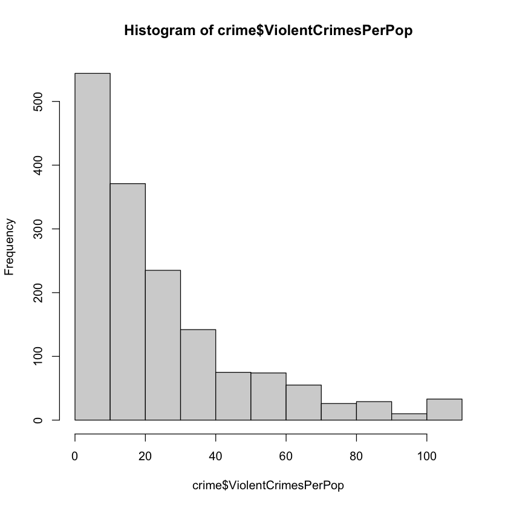

```r
# Code to create a histogram
hist(crime$ViolentCrimesPerPop)
```

**Response to Question 1)**: Yes - the histogram indicates the variable **ViolentCrimesPerPop** follows a poisson distribution and is a rate.

### Question 2-Multiple Linear Regression & Model Fit

a) Create a linear regression model, called **model1**, with *ViolentCrimesPerPop* as the response variable and all other variables as the predictors. Include an intercept. Display the summary table of the model. *Note: Remember to use 'crime' as your data set.*

```r
# Code to create model and summary

model1 <- lm(ViolentCrimesPerPop~., data=crime)
summary(model1)
```

```
Call:
lm(formula = ViolentCrimesPerPop ~ ., data = crime)

Residuals:
    Min      1Q  Median      3Q     Max
-47.313  -9.865  -2.030   5.875  79.252

Coefficients:
                 Estimate Std. Error t value Pr(>|t|)
(Intercept)       -13.781      3.761  -3.664 0.000257 ***
PersPerOccupHous   12.776      3.250   3.931 8.83e-05 ***
PctHousOwnOcc      -3.394      3.744  -0.906 0.364874
MalePctDivorce     47.840      3.047  15.699  < 2e-16 ***
FamIncLow          -2.378      2.484  -0.957 0.338543
FamIncMedium       -4.635      1.931  -2.401 0.016465 *
PctRecImmig8        6.395      2.628   2.433 0.015064 *
NormPopulation     31.608      4.599   6.872 9.06e-12 ***
RentLow            -5.484      2.167  -2.530 0.011493 *
RentMedium          2.001      1.781   1.124 0.261280
PctPopUnderPov     29.969      3.953   7.582 5.78e-14 ***
PctLess9thGrade     5.039      2.987   1.687 0.091828 .
PctUnemployed      10.268      3.670   2.798 0.005207 **
NumStreet          17.246      5.512   3.129 0.001788 **
---
Signif. codes:  0 ‘***’ 0.001 ‘**’ 0.01 ‘*’ 0.05 ‘.’ 0.1 ‘ ’ 1

Residual standard error: 16.29 on 1580 degrees of freedom
Multiple R-squared:  0.5082,	Adjusted R-squared:  0.5042
F-statistic: 125.6 on 13 and 1580 DF,  p-value: < 2.2e-16
```

b) Is the overall regression significant at the $\alpha = 0.01$ level? Explain.

**Response to Question 2b)**

Yes - the overall regression has a p-value $\approx 0$ therefore we can reject the null hypothesis that all of the predictors are 0 and at least one of the coefficients is nonzero. The overall regression is significant.

c) Using **model1**, calculate and plot the Cook's distance for each point. Based on this plot, evaluate whether there are any concerning outliers. Explain your reasoning. *Note: Do not remove any data points.*

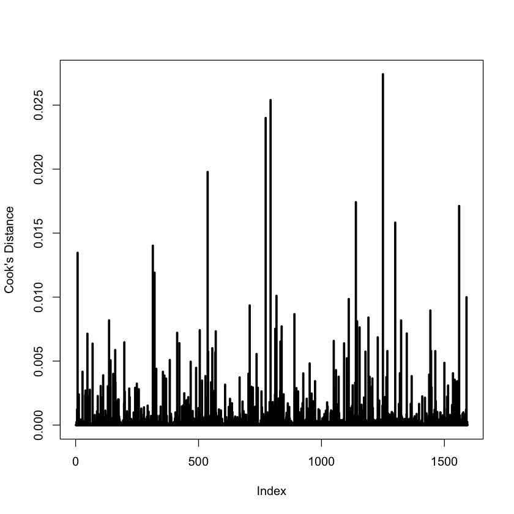

```r
# Code to calculate Cook's distance and plot
cook = cooks.distance(model1)
plot(cook, type="h", lwd=3, ylab="Cook's Distance")
```

```r
4/1594
```

0.00250941028858218

**Response to Question 2c)**

### Question 3-Multiple Linear Regression & Assumptions

Using **model1**, create and interpret the following plots to determine whether the multiple linear regression (MLR) assumptions hold. State which assumption(s) can be assessed by each plot and comment on whether there are any apparent departures from the assumptions and why.

- Plot of the standardized residuals, $r_i$, versus the fitted values, $\hat y_i$.
- Q-Q plot of the standardized residuals, $r_i$.

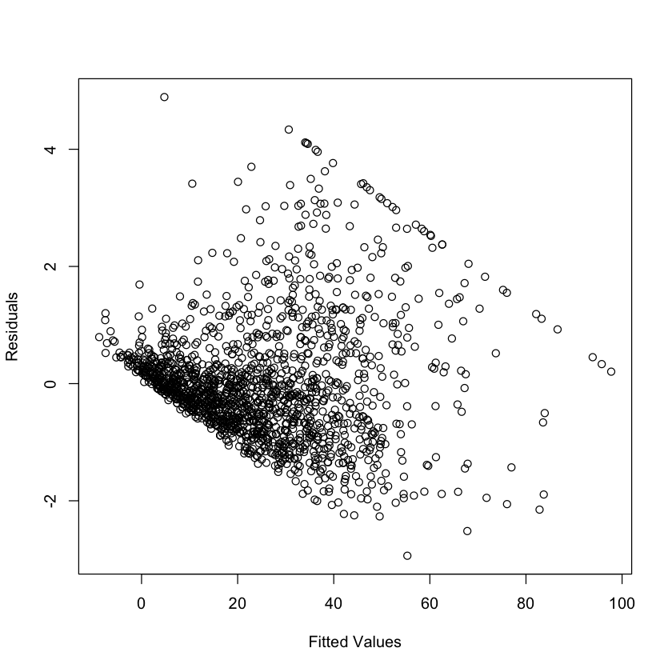

**375**

1140

**83**

1111

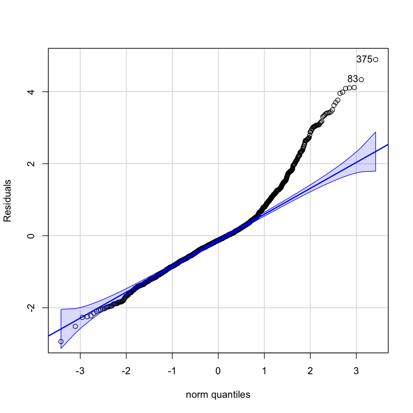

```r
# Code to create plots to check assumptions
fitted = model1$fitted
resid = stdres(model1)

plot(fitted, resid, xlab="Fitted Values", ylab="Residuals")
qqPlot(resid, ylab="Residuals")
```

**Response to Question 3)**:

- Plot of the standardized residuals, $r_i$, versus the fitted values, $\hat y_i$.

Model Assumption(s) it checks: Constant variance and independence

Interpretation: There does not seem to be large clusters of residuals indicating the independence assumption holds. However the magnitude of the variance does seem to change with the fitted values indicated the constant variance assumption does not hold.

- Q-Q plot of the standardized residuals, $r_i$.

Model Assumption(s) it checks: Normality

Interpretation: The q-q plot deviates significant from a straight line indicated the normality assumption does not hold.

### Question 4- Multiple Linear Regression & Fit Improvement

a) Perform a log transformation of the response variable and create a new linear regression model **model2**, with the **transformed** *ViolentCrimesPerPop* as the response variable and all other variables as the predictors (*Do not transform any of the predictor variables*). Include an intercept. Display the summary table of the model. *Note: Remember to use crime as your data set.*

```r
# Code to create model and summary
model2 <- lm(log(ViolentCrimesPerPop)~., data=crime)
summary(model2)
```

```
Call:
lm(formula = log(ViolentCrimesPerPop) ~ ., data = crime)

Residuals:
     Min       1Q   Median       3Q      Max
-2.53790 -0.42440  0.01141  0.42017  2.80090

Coefficients:
                 Estimate Std. Error t value Pr(>|t|)
(Intercept)       0.76719    0.14940   5.135 3.17e-07 ***
PersPerOccupHous  0.42253    0.12910   3.273  0.00109 **
PctHousOwnOcc    -0.12759    0.14872  -0.858  0.39106
MalePctDivorce    2.38255    0.12104  19.684  < 2e-16 ***
FamIncLow         0.12233    0.09865   1.240  0.21517
FamIncMedium      0.10238    0.07668   1.335  0.18201
PctRecImmig8      0.55332    0.10437   5.301 1.31e-07 ***
NormPopulation    1.16383    0.18268   6.371 2.46e-10 ***
RentLow          -0.14418    0.08609  -1.675  0.09418 .
RentMedium        0.11156    0.07074   1.577  0.11498
PctPopUnderPov    1.30221    0.15700   8.294 2.31e-16 ***
PctLess9thGrade   0.18123    0.11866   1.527  0.12687
PctUnemployed     0.29342    0.14577   2.013  0.04429 *
NumStreet        -0.08651    0.21895  -0.395  0.69281
---
Signif. codes:  0 ‘***’ 0.001 ‘**’ 0.01 ‘*’ 0.05 ‘.’ 0.1 ‘ ’ 1

Residual standard error: 0.6469 on 1580 degrees of freedom
Multiple R-squared:  0.5591,	Adjusted R-squared:  0.5554
F-statistic: 154.1 on 13 and 1580 DF,  p-value: < 2.2e-16
```

b) Calculate the variance inflation factor (VIF) for each predicting variable. What is the value of the VIF threshold $max\{10, \frac{1}{1-R^2_{\text{model2}}}\}$ for this model?

```r
# Code to calculate VIF and VIF threshold
vif(model2)

1/(1-summary(model2)$r.squared)
```

A matrix: 11 × 3 of type dbl

|  | GVIF | Df | GVIF^(1/(2*Df)) |
| --- | --- | --- | --- |
| PersPerOccupHous | 1.815603 | 1 | 1.347443 |
| PctHousOwnOcc | 2.964822 | 1 | 1.721866 |
| MalePctDivorce | 1.860814 | 1 | 1.364116 |
| FamInc | 4.738781 | 2 | 1.475423 |
| PctRecImmig8 | 2.291148 | 1 | 1.513654 |
| NormPopulation | 1.872151 | 1 | 1.368266 |
| Rent | 3.822009 | 2 | 1.398212 |
| PctPopUnderPov | 4.734091 | 1 | 2.175797 |
| PctLess9thGrade | 2.370513 | 1 | 1.539647 |
| PctUnemployed | 3.215646 | 1 | 1.793222 |
| NumStreet | 1.819108 | 1 | 1.348743 |

2.26784705864442

**Response to Question 4b)**: The VIF threshold max is 10 since the (1/(1-r2)) is less than 10.

c) Do any of the VIF values exceed the threshold? Based on these results, does multicollinearity seem to be a concern in this model?

**Response to Question 4c)**: No - none of the variables exceed the threshold indicated multicollinearity does not seem to be a concern for this model.

### Question 5-Poisson Regression & Model Fit

a) Fit a Poisson regression model, called **model3**, with *ViolentCrimesPerPop* as the response variable (**Do not use the transformed response variable**) and all other variables as the predictors. Include an intercept. Display the summary table of the model. *Note: Remember to use crime as your data set.*

```r
# Code to fit model

model3 <- glm(ViolentCrimesPerPop~., family="poisson", data=crime)
summary(model3)
```

```
Call:
glm(formula = ViolentCrimesPerPop ~ ., family = "poisson", data = crime)

Deviance Residuals:
    Min       1Q   Median       3Q      Max
-8.4577  -2.1614  -0.7737   1.1123  16.4734

Coefficients:
                 Estimate Std. Error z value Pr(>|z|)
(Intercept)       1.47667    0.05138  28.738  < 2e-16 ***
PersPerOccupHous  0.31810    0.04158   7.651 2.00e-14 ***
PctHousOwnOcc    -0.34459    0.04476  -7.699 1.37e-14 ***
MalePctDivorce    1.91076    0.03569  53.535  < 2e-16 ***
FamIncLow         0.23736    0.04111   5.774 7.74e-09 ***
FamIncMedium      0.09760    0.03658   2.668 0.007638 **
PctRecImmig8      0.33564    0.03062  10.963  < 2e-16 ***
NormPopulation    0.76492    0.04006  19.096  < 2e-16 ***
RentLow          -0.12559    0.03448  -3.642 0.000271 ***
RentMedium        0.09482    0.03035   3.125 0.001780 **
PctPopUnderPov    1.02777    0.04512  22.776  < 2e-16 ***
PctLess9thGrade   0.13836    0.03547   3.901 9.59e-05 ***
PctUnemployed     0.27103    0.04185   6.476 9.40e-11 ***
NumStreet        -0.02176    0.04800  -0.453 0.650222
---
Signif. codes:  0 ‘***’ 0.001 ‘**’ 0.01 ‘*’ 0.05 ‘.’ 0.1 ‘ ’ 1

(Dispersion parameter for poisson family taken to be 1)

    Null deviance: 29557  on 1593  degrees of freedom
Residual deviance: 13223  on 1580  degrees of freedom
AIC: 20634

Number of Fisher Scoring iterations: 5
```

b) Examine the summary tables for **model2** and **model3**. Is there any significant change in the direction and/or statistical significance of the regression coefficients? If so, list one change. Use $\alpha = 0.01$ significance level.

```r
# Code to display summaries (if needed)
summary(model2)
```

```
Call:
lm(formula = log(ViolentCrimesPerPop) ~ ., data = crime)

Residuals:
     Min       1Q   Median       3Q      Max
-2.53790 -0.42440  0.01141  0.42017  2.80090

Coefficients:
                 Estimate Std. Error t value Pr(>|t|)
(Intercept)       0.76719    0.14940   5.135 3.17e-07 ***
PersPerOccupHous  0.42253    0.12910   3.273  0.00109 **
PctHousOwnOcc    -0.12759    0.14872  -0.858  0.39106
MalePctDivorce    2.38255    0.12104  19.684  < 2e-16 ***
FamIncLow         0.12233    0.09865   1.240  0.21517
FamIncMedium      0.10238    0.07668   1.335  0.18201
PctRecImmig8      0.55332    0.10437   5.301 1.31e-07 ***
NormPopulation    1.16383    0.18268   6.371 2.46e-10 ***
RentLow          -0.14418    0.08609  -1.675  0.09418 .
RentMedium        0.11156    0.07074   1.577  0.11498
PctPopUnderPov    1.30221    0.15700   8.294 2.31e-16 ***
PctLess9thGrade   0.18123    0.11866   1.527  0.12687
PctUnemployed     0.29342    0.14577   2.013  0.04429 *
NumStreet        -0.08651    0.21895  -0.395  0.69281
---
Signif. codes:  0 ‘***’ 0.001 ‘**’ 0.01 ‘*’ 0.05 ‘.’ 0.1 ‘ ’ 1

Residual standard error: 0.6469 on 1580 degrees of freedom
Multiple R-squared:  0.5591,	Adjusted R-squared:  0.5554
F-statistic: 154.1 on 13 and 1580 DF,  p-value: < 2.2e-16
```

**Response to Question 5b)**: Yes - there does seem to be significant change in the statistical significance of at least of the predictors. For instance **PctHousOwnOcc** which is the percent of of households owner occupied is now statistically significant (in model3) and was not statistically significant in model2.

### Question 6-Poisson Regression & Coefficient Interpretation

a) Interpret the estimated regression coefficients for the predictor variable *FamIncLow* in the context of **model3**. *Note: Make sure that you are treating High as the baseline level.*

```r
# Code to extract estimated coefficients (if needed)
```

**Response to Question 6a)**: When the the the family income category is low, the log expected violent crimes per population increases by 0.23736 over the baseline which is when the family income category is high, keeping all other variables constant.

b) Provide a 95% confidence interval for *PctPopUnderPov* coefficient in **model3**. Exponentiate the endpoints of the confidence interval and interpret it in the context of the problem.

```r
# Code to compute confidence interval
confint(model3, "FamIncLow", level=0.95)
```

**2.5 %**

0.157098360846853

**97.5 %**

0.318249577982

### Question 7-Poisson Regression & Goodness of Fit

a) Estimate the dispersion parameter for **model3**. Is this an overdispersed model? Explain.

```r
# Code to estimate dispersion parameter
sum(residuals(model3, type = "deviance")^2)/model3$df.residual
```

8.36896570902946

**Response to Question 7a)**: Yes the model is overdispersed because the overdispersion parameter is greater than 2.

b) Perform a goodness-of-fit hypothesis test for **model3** using the deviance residuals and $\alpha = 0.05$. State the hypothesis of this test. What do you conclude? Explain.

```r
# Code to perform hypothesis test
1-pchisq(deviance(model3), 1580)
```

0

**Response to Question 7b)**: The null hypothesis is that the model is that that the model is a good fit to the data. The p-value is less than 0.05; therefore we reject the null hypothesis of a good fit and conclude that model3 is not a good fit to the data.

c) Based on the previous assessments, what would you suggest to improve the fit of the model and why? *One suggestion will suffice.*

**Response to Question 7c)**: In this case we could remove some of the outliers previously identified or transofrm the predicting variable to try and improve the fit.

### Question 8-Poisson Regression & Test for Subset of Coefficients

Are at least one of the variables *PctLess9thGrade*, *PctUnemployed* and *NumStreet* statistically significant at the $\alpha = 0.01$ level, given all of the other variables in **model3** are included? Perform a testing for subset of coefficients to answer this question. Explain your reasoning, including a statement of the null and alternative hypotheses.

```r
# Code to perform testing
wald.test(b=coef(model3), Sigma=vcov(model3), Terms=11:13)
```

```
Wald test:
----------

Chi-squared test:
X2 = 1417.9, df = 3, P(> X2) = 0.0
```

### Question 9-Prediction & Model Evaluation

a) Estimate *ViolentCrimesPerPop* for the test set **crime_test** using both **model2** and **model3**. Use the R function "head()" to show the first few predictions for each model.

```r
# Code to calculate estimates and show first estimates
crime_test$pred2 = exp(predict(model2, crime_test,type='response'))
crime_test$pred3 = predict(model3, crime_test, type='response')

head(crime_test$pred2)
head(crime_test$pred3)
```

1. 6.271400951488

2. 6.85202633696871

3. 5.38651190786405

4. 6.7879738887641

5. 21.5156657243727

6. 8.49277404944822

1. 8.39132371565065

2. 9.88861467519961

3. 7.75717812502601

4. 9.56866456948203

5. 28.5416584599238

6. 11.662857069511

b) Calculate the precision error (PM) of each model.

```r
# Code to calculate PM
sum((crime_test$pred2-crime_test$ViolentCrimesPerPop)^2)/sum((crime_test$pred2-mean(crime_test$ViolentCrimesPerPop))^2)
sum((crime_test$pred3-crime_test$ViolentCrimesPerPop)^2)/sum((crime_test$pred3-mean(crime_test$ViolentCrimesPerPop))^2)
```

0.726782297812891

0.756648480242715

**Response to Question 9b)**:

*PM Model2*: 0.727

*PM Model3*: 0.757

c) Compare the results from part b). Which model performed the best based on this metric? Explain.

**Response to Question 9c)**: The precision metric of model2 is lower than that of model3 indicating model2 performs better based on this metric.

**The end**